# Marketing Picked the Market. Which Estimator Should You Trust?

Many of the most expensive decisions a consumer app makes, like marketing campaigns, regional launches, or pricing changes, happen at the market level, where **randomizing individual users is impossible.** For a family safety app, a back-to-school campaign is a natural example: it runs in one metro, it lands during the season when parents are most likely to subscribe anyway, and the metro was not chosen at random. Sometimes it is the company's biggest market, and sometimes it is the market that already looked the most promising.

This notebook simulates both versions of that decision with a known true effect and compares two standard ways of measuring it. **Difference-in-differences compares the treated metro to the average of all other metros, while synthetic control builds a custom comparison out of the metros that most closely track the treated one before the campaign.** The takeaway is that neither method wins everywhere. When marketing picks a large market that grows like everyone else, DiD recovers the true effect and synthetic control is biased, because matching an unusually high baseline forces it to lean on a few big metros that behave differently. When marketing picks a market because it was already growing fast, the result flips: DiD credits the campaign with growth and seasonality that would have happened anyway, and synthetic control recovers the true effect. The real lesson is to check which assumption your data can support before choosing an estimator.

## 1. Setup: Did the Back-to-School Campaign Drive Premium Subscriptions?

A family safety app with a free tier and a paid premium membership runs a regional back-to-school marketing campaign (TV, streaming, and billboards) in one metro area, promoting its premium features to parents. Leadership wants to know how many incremental paid subscriptions the campaign generated, to decide whether to roll it out nationally. The campaign runs at the market level, so there is no user-level randomization: every household in the metro is exposed, and no household outside it is. The only option is to compare the treated metro against the other metros that did not get the campaign.

The comparison gets tricky in a different way depending on how marketing picked the metro, so we simulate two scenarios:

- **Scenario A: a top market.** Marketing launches in one of its largest metros. Baseline subscriptions are much higher than in the typical metro, but organic growth and back-to-school sensitivity are average. Parallel trends holds against the full set of controls.
- **Scenario B: a hand-picked growth market.** Marketing chooses a mid-size metro because premium adoption was already growing fast there, and it reacts more strongly than average to the back-to-school spike, which the campaign launches right before. Parallel trends does not hold.

Difference-in-differences compares the treated metro to the *average* control metro after removing each metro's baseline level. A high baseline does not matter to it, but a steeper trend or a stronger seasonal spike leaks straight into its estimate. Synthetic control has the opposite profile. It builds a weighted combination of control metros that matches the treated metro's pre-campaign path, level included, which means it can absorb faster growth and stronger seasonality, *as long as some control metros look similar enough* to combine into a match. When the treated metro sits near the top of the level distribution, only a handful of controls can get there, and their growth and seasonality come along with them.

## 2. Data Generating Process

We observe $J + 1$ metro areas over $T$ weeks. Metro $j = 0$ receives the campaign starting in week $T_0$; metros $j = 1, \dots, J$ never do. The outcome $Y_{jt}$ is weekly new premium subscriptions per 100,000 households.

**Untreated potential outcome.** Absent the campaign, subscriptions follow a factor model:

$$ Y_{jt}(0) = \alpha_j + \delta_t + \gamma_j \, t + \lambda_j \, f_t + \varepsilon_{jt}, \qquad \varepsilon_{jt} \sim N(0, \sigma^2) $$

where:

- $\alpha_j \sim N(\mu_\alpha, \sigma_\alpha^2)$ is the metro's baseline subscription level (market size, awareness, income).
- $\delta_t$ is a national shock common to all metros (app store features, national news), drawn as a random walk: $\delta_t = \delta_{t-1} + \nu_t$, $\nu_t \sim N(0, \sigma_\nu^2)$.
- $\gamma_j \sim U(\gamma_{min}, \gamma_{max})$ is the metro's organic growth rate in premium adoption.
- $f_t$ is the back-to-school seasonal factor, shared by all metros, peaking at the week school starts ($w^*$ in week-of-year terms, with spread $s$):

$$ f_t = \exp\left(-\frac{(w(t) - w^*)^2}{2 s^2}\right), \qquad w(t) = \big((t - 1) \bmod 52\big) + 1 $$

- $\lambda_j \sim U(\lambda_{min}, \lambda_{max})$ is the metro's sensitivity to the back-to-school season.

**The treated metro.** Rather than drawing at random, the treated metro's parameters are set to reflect how marketing picked it. Both scenarios share the same control metros, shocks, and noise; only metro $0$ changes:

$$ \text{Scenario A (top market):} \quad \alpha_0 \gg \bar{\alpha}_{\text{controls}}, \qquad \gamma_0 = \bar{\gamma}_{\text{controls}}, \qquad \lambda_0 = \bar{\lambda}_{\text{controls}} $$

$$ \text{Scenario B (growth market):} \quad \gamma_0 > \bar{\gamma}_{\text{controls}}, \qquad \lambda_0 > \bar{\lambda}_{\text{controls}} $$

In both scenarios, every parameter of the treated metro stays *inside* the range of the control metros, so in principle a weighted combination of controls can reproduce its path. Scenario A places $\alpha_0$ near the top of that range, where very few controls can help.

**Treatment.** The campaign adds a constant effect $\tau$ from week $T_0$ onward:

$$ Y_{jt} = Y_{jt}(0) + \tau \cdot D_{jt}, \qquad D_{jt} = \mathbb{1}[j = 0] \cdot \mathbb{1}[t \geq T_0] $$

**Why DiD fails in Scenario B.** DiD recovers $\tau$ only if the treated metro's untreated path would have moved in parallel with the control average. The metro fixed effect absorbs any difference in $\alpha$, so the bias depends only on growth and seasonality:

$$ \text{Bias}_{DiD} \approx \underbrace{(\gamma_0 - \bar{\gamma}_{co})(\bar{t}_{post} - \bar{t}_{pre})}_{\text{faster growth}} + \underbrace{(\lambda_0 - \bar{\lambda}_{co})(\bar{f}_{post} - \bar{f}_{pre})}_{\text{stronger seasonal spike}} $$

In Scenario A both terms are zero, so DiD is unbiased no matter how large the metro is. In Scenario B both terms are positive: the treated metro was growing faster and the post period contains the seasonal peak, so DiD credits the campaign with growth and seasonality that would have happened anyway.

**Why synthetic control fails in Scenario A.** Synthetic control has no intercept: its counterfactual is a weighted average of control outcomes, with weights $w_j \geq 0$ that sum to one. Its bias is whatever gap in level, growth, and seasonality the weights fail to close:

$$ \text{Bias}_{SC} \approx \underbrace{\Big(\alpha_0 - \sum_j w_j \alpha_j\Big)}_{\text{level gap}} + \underbrace{\Big(\gamma_0 - \sum_j w_j \gamma_j\Big)\bar{t}_{post}}_{\text{growth gap}} + \underbrace{\Big(\lambda_0 - \sum_j w_j \lambda_j\Big)\bar{f}_{post}}_{\text{seasonal gap}} $$

In Scenario B the treated metro has a typical level, so the weights are free to match its growth and seasonality, which drives all three terms toward zero. In Scenario A, reaching a baseline near the top of the distribution forces the weights onto the few largest control metros, and their growth rates and seasonal sensitivities come along whether they match or not. The pre-period fit can still look reasonable, but the growth and seasonal gaps compound after the launch, right as the back-to-school peak arrives.

```python
import pandas as pd
import numpy as np
import matplotlib.pyplot as plt
import seaborn as sns
import statsmodels.formula.api as smf
```

```python
# Simulate Cities
np.random.seed(2026)
J = 41 #number of Cities (lets make the first city the treated one)
T = 104 #Two years of weekly data
T_0 = 82 #campaign starts ~2 weeks before year-two school start

#Simulate metro level variables
mu_alpha      = 50 #baseline mean of subscriptions
sigma_alpha   = 10
#organic weekly growth
gamma_jlow , gamma_jhigh  = 0,0.15
gamma0        = 0.11 #treated metro growth, above the control mean of ~0.075
#seasonal sensitivity
lambda_jlow,lambda_jhigh   = 5,15
lambda0       = 13 #treated metro sensitivity, above the control mean of ~10

alpha0_benign = 70          #benign launch metro is a top market (controls max ~77)


metro_level_data = pd.DataFrame(
    {
        "metro_id": np.arange(1,J+1),
        "D_j": np.concatenate(([1], np.repeat(0, J-1))),
        "alpha_j":np.random.normal(loc=mu_alpha,scale=sigma_alpha,size=J),
        "gamma_j":np.random.uniform(gamma_jlow,gamma_jhigh,J),
        "lambda_j":np.random.uniform(lambda_jlow,lambda_jhigh,J)
    }
)


#Set Seasonality and organic growth for treated city
metro_level_data.loc[0,'gamma_j'] = gamma0
metro_level_data.loc[0,'lambda_j'] = lambda0

# calculate means for the benign case
metro_level_data_controls = metro_level_data.iloc[1:]

mean_params = metro_level_data_controls[['gamma_j','lambda_j']].mean()

metro_level_data['gamma_j_benign'] = np.where(metro_level_data['D_j']==1, mean_params['gamma_j'],metro_level_data['gamma_j'])
metro_level_data['lambda_j_benign'] = np.where(metro_level_data['D_j']==1, mean_params['lambda_j'],metro_level_data['lambda_j'])
metro_level_data['alpha_j_benign'] = np.where(metro_level_data['D_j']==1, alpha0_benign, metro_level_data['alpha_j'])

#Simulate time variables
sigma_v  = 0.3 #national shock volatility
delta0   = 0
delta    = np.zeros(T)
delta[0] = delta0

#school starts around week 32 (early August), spike lasts a few weeks
w_star, s =32, 3
f0       = np.exp(- (1-w_star)**2/(2*s**2))
f = np.zeros(T)
f[0]     = f0
for t in range(1,len(delta)):
  delta[t] = delta[t-1] + np.random.normal(loc=0,scale=sigma_v )
  wt     = t%52+1
  f[t]   = np.exp( -(wt-w_star)**2/(2*s**2))

time_variables = pd.DataFrame({
  "t": np.arange(1,T+1),
  "delta_t":delta,
  "f_t": f
})

#Now simulate panel data
sigma    = 2 #weekly noise
panel_data = pd.DataFrame({"metro_id":  np.repeat(np.arange(1,J+1), T) ,
                         "e_jt":np.random.normal(loc=0,scale=sigma,size=J*T)})

panel_data['t'] = panel_data.groupby(['metro_id']).cumcount() +1 # generate the weekly period variable


experiment_data = pd.merge(panel_data,metro_level_data, on= 'metro_id', how='left').merge(time_variables,how='left',on='t')
experiment_data

#Now simulate DGP
tau = 4 #true campaign effect (subscriptions per 100k per week)
experiment_data['post']       = (experiment_data['t'] >= T_0).astype(int)
experiment_data['pre']        = (experiment_data['t'] < T_0).astype(int)
experiment_data['D_jt']       = experiment_data['D_j'] *experiment_data['post']
experiment_data['y_jt']       = experiment_data['alpha_j'] + experiment_data['delta_t'] + experiment_data['gamma_j']*experiment_data['t']  +experiment_data['lambda_j']*experiment_data['f_t'] + tau*experiment_data['D_jt'] + experiment_data['e_jt']
experiment_data['y_jtbenign'] = experiment_data['alpha_j_benign'] + experiment_data['delta_t'] + experiment_data['gamma_j_benign']*experiment_data['t']  +experiment_data['lambda_j_benign']*experiment_data['f_t'] + tau*experiment_data['D_jt'] +experiment_data['e_jt']
#print(experiment_data)
#print(mean_params)  # realized control means of gamma and lambda
print(metro_level_data_controls[['gamma_j','lambda_j']].describe())
print(metro_level_data.loc[0, ['alpha_j', 'gamma_j', 'lambda_j']])
print(metro_level_data_controls[['alpha_j', 'gamma_j', 'lambda_j']].describe())
```

```
         gamma_j   lambda_j
count  40.000000  40.000000
mean    0.083187  10.669309
std     0.044155   2.713839
min     0.008765   5.560701
25%     0.041445   8.353021
50%     0.089865  10.893985
75%     0.122994  12.812759
max     0.149610  14.861292
alpha_j     45.682815
gamma_j      0.110000
lambda_j    13.000000
Name: 0, dtype: float64
         alpha_j    gamma_j   lambda_j
count  40.000000  40.000000  40.000000
mean   49.570266   0.083187  10.669309
std    10.863376   0.044155   2.713839
min    22.751409   0.008765   5.560701
25%    43.956429   0.041445   8.353021
50%    49.883189   0.089865  10.893985
75%    55.155944   0.122994  12.812759
max    77.297500   0.149610  14.861292
```

## 2. Estimate Models and Compare

```python
#Dif in Diff
model_benign = smf.ols(formula='y_jtbenign~D_j + post + D_j:post +t+delta_t +C(metro_id)-1',data=experiment_data).fit(
    cov_type='cluster', cov_kwds={'groups': experiment_data['metro_id']}
)

model_seasonality = smf.ols(formula='y_jt~D_j + post + D_j:post +t+delta_t +C(metro_id)-1',data=experiment_data).fit(
    cov_type='cluster', cov_kwds={'groups': experiment_data['metro_id']}
)

print(model_benign.summary())
print(model_seasonality.summary())
```

```
                            OLS Regression Results
==============================================================================
Dep. Variable:             y_jtbenign   R-squared:                       0.904
Model:                            OLS   Adj. R-squared:                  0.903
Method:                 Least Squares   F-statistic:                       nan
Date:                Tue, 06 Oct 2026   Prob (F-statistic):                nan
Time:                        11:34:01   Log-Likelihood:                -11674.
No. Observations:                4264   AIC:                         2.344e+04
Df Residuals:                    4219   BIC:                         2.372e+04
Df Model:                          44
Covariance Type:              cluster
===================================================================================
                      coef    std err          z      P>|z|      [0.025      0.975]
-----------------------------------------------------------------------------------
C(metro_id)[1]     35.4478      0.139    254.318      0.000      35.175      35.721
C(metro_id)[2]     38.5295      0.358    107.580      0.000      37.828      39.231
C(metro_id)[3]     54.5119      0.358    152.206      0.000      53.810      55.214
C(metro_id)[4]     51.6805      0.358    144.300      0.000      50.979      52.382
C(metro_id)[5]     65.6898      0.358    183.416      0.000      64.988      66.392
C(metro_id)[6]     49.9460      0.358    139.457      0.000      49.244      50.648
C(metro_id)[7]     46.3271      0.358    129.352      0.000      45.625      47.029
C(metro_id)[8]     35.3930      0.358     98.823      0.000      34.691      36.095
C(metro_id)[9]     54.5889      0.358    152.420      0.000      53.887      55.291
C(metro_id)[10]    50.5001      0.358    141.004      0.000      49.798      51.202
C(metro_id)[11]    46.7560      0.358    130.550      0.000      46.054      47.458
C(metro_id)[12]    43.6568      0.358    121.897      0.000      42.955      44.359
C(metro_id)[13]    30.7779      0.358     85.937      0.000      30.076      31.480
C(metro_id)[14]    58.4666      0.358    163.248      0.000      57.765      59.169
C(metro_id)[15]    55.2386      0.358    154.235      0.000      54.537      55.941
C(metro_id)[16]    52.9434      0.358    147.826      0.000      52.241      53.645
C(metro_id)[17]    54.4057      0.358    151.909      0.000      53.704      55.108
C(metro_id)[18]    39.1642      0.358    109.352      0.000      38.462      39.866
C(metro_id)[19]    66.8390      0.358    186.625      0.000      66.137      67.541
C(metro_id)[20]    45.5908      0.358    127.296      0.000      44.889      46.293
C(metro_id)[21]    56.2748      0.358    157.128      0.000      55.573      56.977
C(metro_id)[22]    60.1027      0.358    167.816      0.000      59.401      60.805
C(metro_id)[23]    21.4892      0.358     60.001      0.000      20.787      22.191
C(metro_id)[24]    69.4584      0.358    193.938      0.000      68.756      70.160
C(metro_id)[25]    53.3449      0.358    148.947      0.000      52.643      54.047
C(metro_id)[26]    37.0706      0.358    103.507      0.000      36.369      37.773
```

[output cut: 87 more lines]

```
post                2.7010      0.156     17.286      0.000       2.395       3.007
D_j:post            5.2656      0.374     14.065      0.000       4.532       5.999
t                   0.0092      0.007      1.343      0.179      -0.004       0.023
delta_t             2.4784      0.086     28.948      0.000       2.311       2.646
==============================================================================
Omnibus:                      390.875   Durbin-Watson:                   0.667
Prob(Omnibus):                  0.000   Jarque-Bera (JB):              538.000
Skew:                           0.745   Prob(JB):                    1.50e-117
Kurtosis:                       3.898   Cond. No.                     1.69e+18
==============================================================================

Notes:
[1] Standard Errors are robust to cluster correlation (cluster)
[2] The smallest eigenvalue is 5.47e-30. This might indicate that there are
strong multicollinearity problems or that the design matrix is singular.
```

[output not shown]

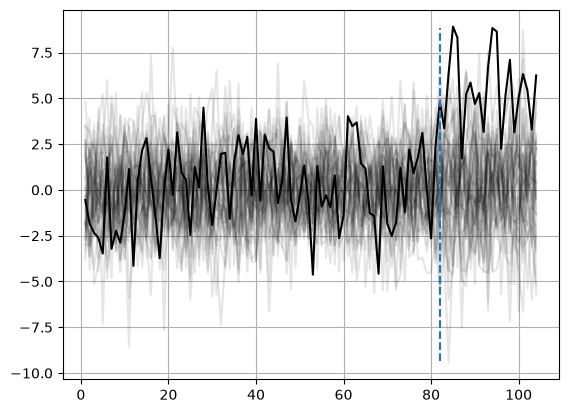

[output not shown]

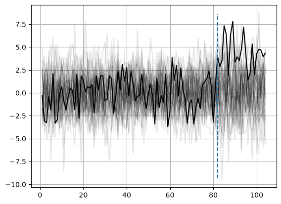

```python
#Synthetic controls
from pysyncon import Dataprep, Synth
from pysyncon.utils import PlaceboTest
#prep data
pre_weeks = range(1, T_0)          # weeks 1..81
post_weeks = range(T_0, T + 1)     # weeks 82..104
V = np.ones(len(pre_weeks)) / len(pre_weeks)    # same V you used for the main fit

synth_data_benign = Dataprep(
    foo=experiment_data,
    predictors=[],
    predictors_op="mean",
    special_predictors=[("y_jtbenign", [w], "mean") for w in pre_weeks],
    dependent="y_jtbenign",
    time_predictors_prior=pre_weeks,
    time_optimize_ssr=pre_weeks,
    unit_variable="metro_id",
    time_variable="t",
    treatment_identifier=1,
    controls_identifier=list(range(2, J + 1)),
)

synth_data_seasonality = Dataprep(
    foo=experiment_data,
    predictors=[],
    predictors_op="mean",
    special_predictors=[("y_jt", [w], "mean") for w in pre_weeks],
    dependent="y_jt",
    time_predictors_prior=pre_weeks,
    time_optimize_ssr=pre_weeks,
    unit_variable="metro_id",
    time_variable="t",
    treatment_identifier=1,
    controls_identifier=list(range(2, J + 1)),
)
#Now estimate both methods
synth_benign = Synth()
synth_benign.fit(dataprep=synth_data_benign, custom_V=V)
att_benign = synth_benign.att(time_period=post_weeks)
print(att_benign)


#Now estimate both methods
synth_seasonality = Synth()
synth_seasonality.fit(dataprep=synth_data_seasonality, custom_V=V)
att_seasonality =synth_seasonality.att(time_period=post_weeks)
print(att_seasonality)
#Placebo Tests

placebo_benign = PlaceboTest()
placebo_benign.fit(
    dataprep=synth_data_benign,
    scm=synth_benign,
    scm_options={"custom_V": V},   # so every placebo uses the same setup as the real fit
)

# p-value: share of placebo metros whose post/pre fit ratio is at least as large as the treated metro's
placebo_benign.pvalue(treatment_time=T_0)

# chart: treated metro's gap in black, the 40 placebo gaps in gray
placebo_benign.gaps_plot(
    time_period=range(1, T + 1),
    treatment_time=T_0,
    mspe_threshold=5,     # drop placebos whose pre-period fit is 5x worse than the treated one
)


placebo_seasonality = PlaceboTest()

placebo_seasonality.fit(
    dataprep=synth_data_seasonality,
    scm=synth_seasonality,
    scm_options={"custom_V": V},   # so every placebo uses the same setup as the real fit
)

# p-value: share of placebo metros whose post/pre fit ratio is at least as large as the treated metro's
placebo_seasonality.pvalue(treatment_time=T_0)

# chart: treated metro's gap in black, the 40 placebo gaps in gray
placebo_seasonality.gaps_plot(
    time_period=range(1, T + 1),
    treatment_time=T_0,
    mspe_threshold=5,     # drop placebos whose pre-period fit is 5x worse than the treated one
)
```

```
   Scenario             Method    Effect  Standard Error     x
0    Benign       Diff-In-Diff  3.522576        0.374388 -0.12
1    Benign  Synthetic Control  5.473370        0.430125  0.12
2  Selected       Diff-In-Diff  5.265606        0.374388  0.88
3  Selected  Synthetic Control  4.357887        0.369119  1.12
```

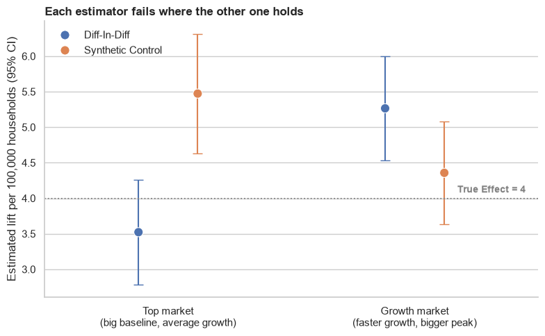

```python
 #Now lets build a comparison chart
results = pd.DataFrame(
    {
        'Scenario': ['Benign','Benign','Selected','Selected'],
        'Method': ['Diff-In-Diff','Synthetic Control','Diff-In-Diff','Synthetic Control'],
        'Effect': [model_benign.params['D_j:post'],att_benign['att'],model_seasonality.params['D_j:post'],att_seasonality['att']],
        'Standard Error':[model_benign.bse['D_j:post'],att_benign['se'],model_seasonality.bse['D_j:post'],att_seasonality['se']]
    }
)
results["x"] = results["Scenario"].map({"Benign": 0, "Selected": 1}) \
             + results["Method"].map({"Diff-In-Diff": -0.12, "Synthetic Control": 0.12})

print(results)

palette = {"Diff-In-Diff": "#4C72B0", "Synthetic Control": "#DD8452"}  # Muted navy vs. warm amber

#Theme and plot starter
sns.set_theme(style="whitegrid")
fig, ax = plt.subplots(figsize=(8, 5))

sns.scatterplot(data=results,x="x",y="Effect", hue="Method",palette=palette,s=90,zorder=3,ax=ax)

# seaborn can't take precomputed SEs, so draw the 95% CIs with errorbar
for _, row in results.iterrows():
    ax.errorbar(row["x"], row["Effect"], yerr=1.96 * row["Standard Error"],
                color=palette[row["Method"]], capsize=5, linewidth=1.5, zorder=2)



ax.axhline(tau, color="gray", linestyle=":", linewidth=1.3)
ax.text(1.45, tau + 0.08, f"True Effect = {tau}", color="gray", ha="right", fontsize=10, weight="bold")

ax.set_xticks([0, 1])
ax.set_xticklabels(["Top market\n(big baseline, average growth)", "Growth market\n(faster growth, bigger peak)"])

ax.set_xlim(-0.5, 1.5)
ax.grid(axis="x", visible=False)
ax.set_xlabel("")
ax.set_ylabel("Estimated lift per 100,000 households (95% CI)")
ax.set_title("Each estimator fails where the other one holds", loc="left", fontsize=12, weight="bold")
ax.legend(title="", frameon=False, loc="upper left")
sns.despine()
plt.tight_layout()
plt.savefig("G:/My Drive/Projects/Synthetic Control Vs Dif-in-Dif/estimate_comparisons.png",
            dpi=300, bbox_inches='tight')
plt.show()
```